# Forecasting - Volatility

## Forecasting volatility

Read in the data we obtained in Phase 1. We calculate simple returns.

Plotting returns:

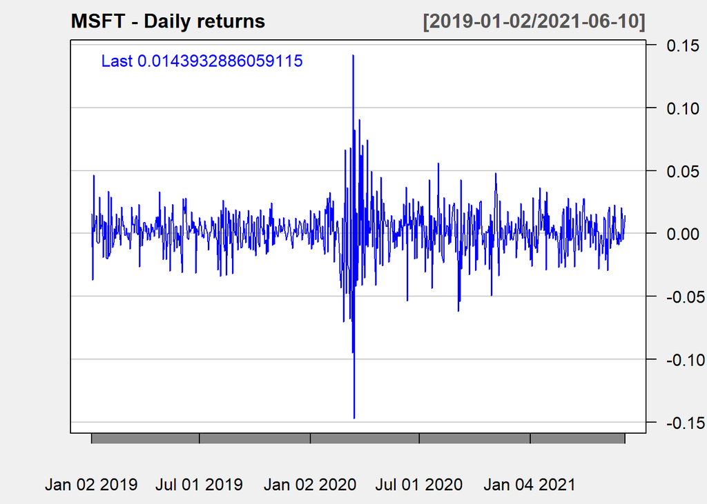

### Splitting the data

We split the data on the in-sample (training) set and out-of-sample (testing) set.

We split the data the same way as in Phase 2 and 3.

```
## [1] "Number of observations in training set: 505 (82.11%)"
```

```
## [1] "Number of observations in testing set: 110 (17.89%)"
```

Looking at ACF and PACF plots we see that there’s serial correlation.

We take a look at regular, squared and absolute values for lag 10 and 30.

PACF plots show the same.

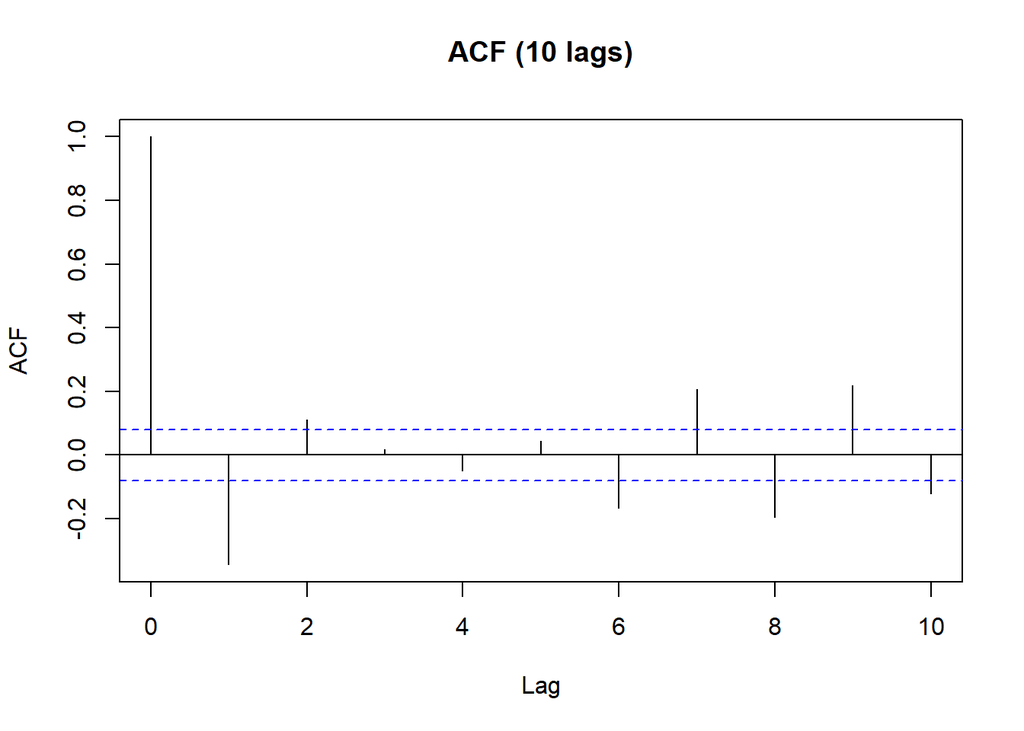

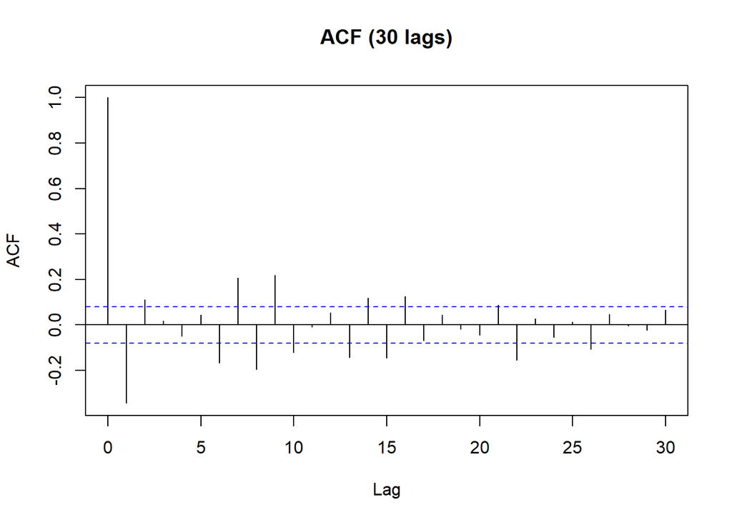

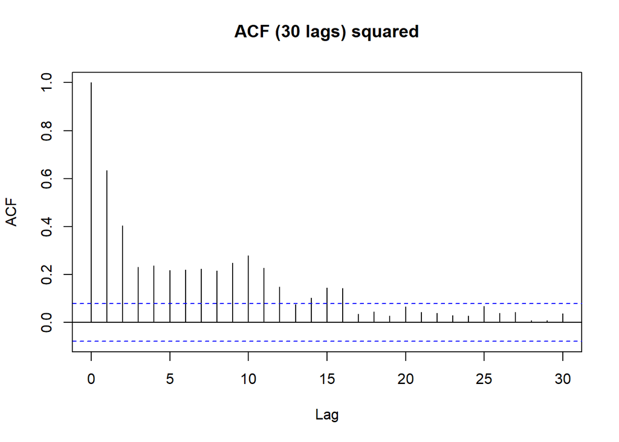

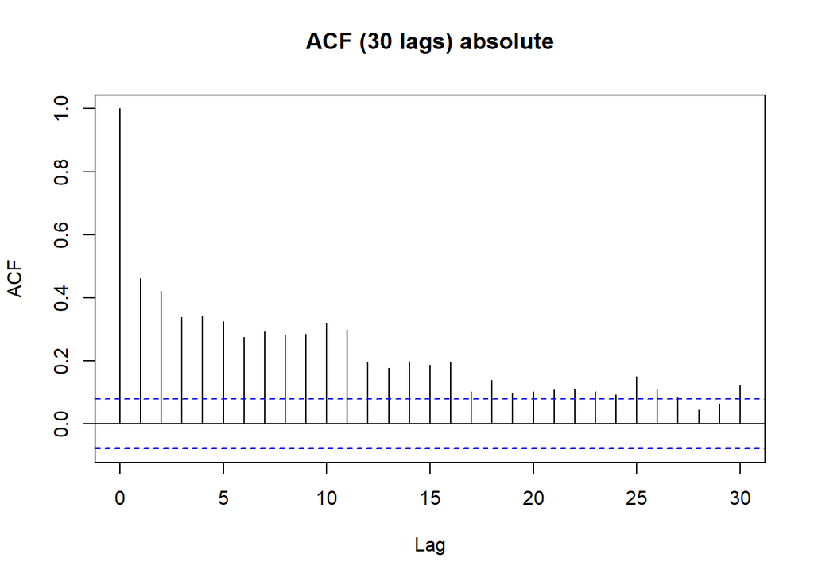

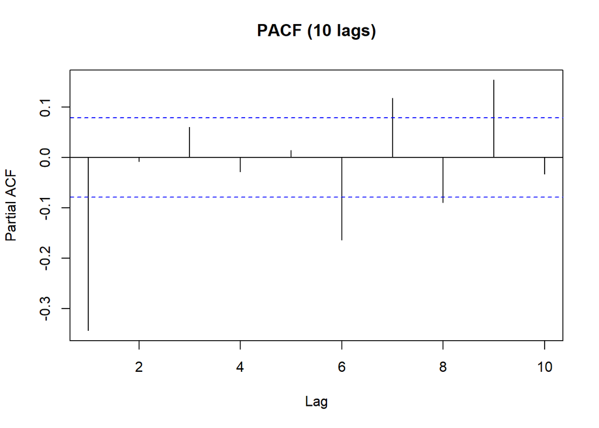

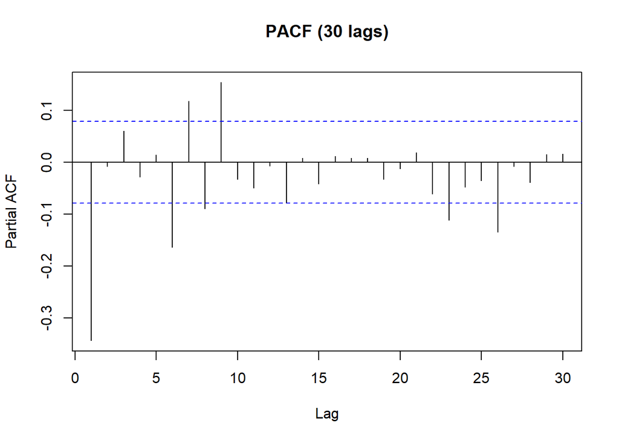

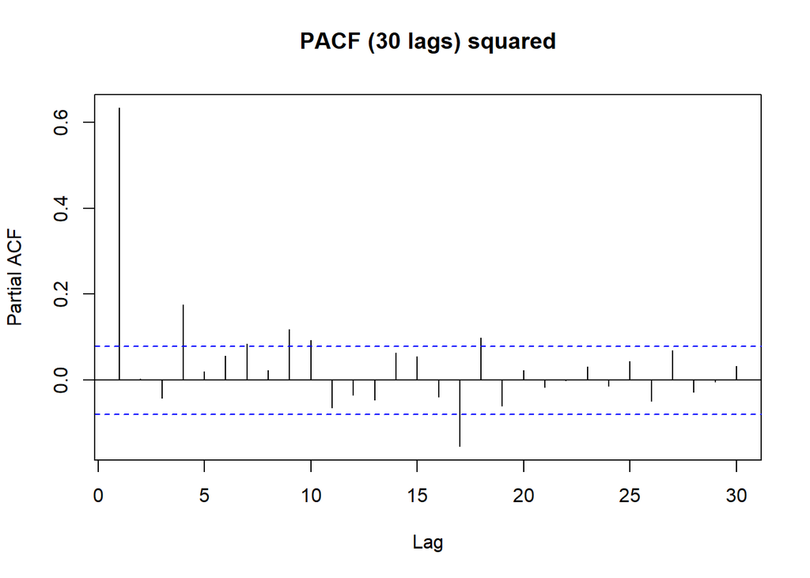

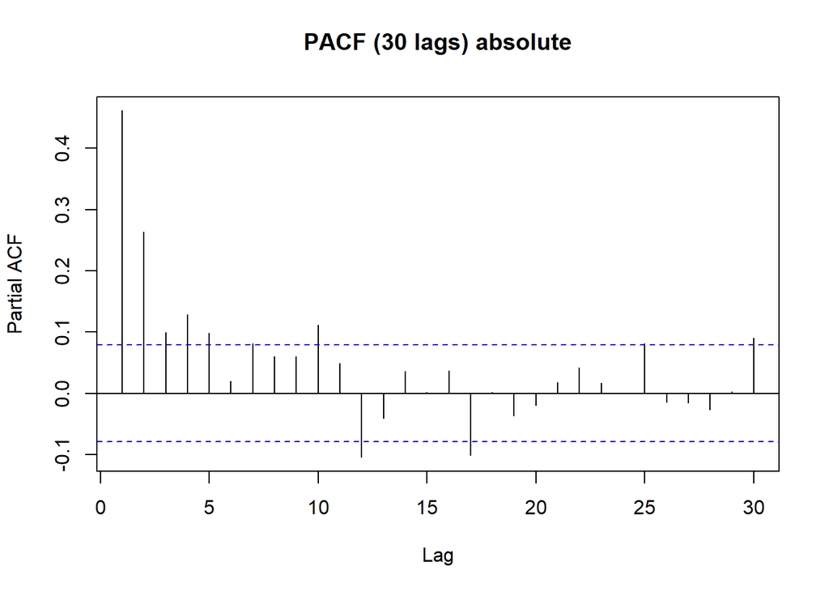

We use Box-Ljung test to test serial correlation on the returns.

Since the p-value is less than 5% we reject the null hypothesis that there is no serial correlation with strong evidence (p-value = 2.2e-16), i.e. there is serial correlation.

This means that we’ll need to use ARMA + GARCH model.

```
##
##  Box-Ljung test
##
## data:  training_set
## X-squared = 271.45, df = 30, p-value < 2.2e-16
```

We need to check if there’s a ARCH effect in the data.

Since the expected return of MSFT is not zero (calculated in Phase 1) we need to adjust for that.

Since p-value is practically zero (2.2e-16), we reject the null hypothesis (that there’s no conditional homoscedastcity).

This means that we have strong evidence to reject this hypothesis, hence, there’s ARCH effect.

```
##
##  Box-Ljung test
##
## data:  at^2
## X-squared = 593.01, df = 30, p-value < 2.2e-16
```

```
##
## Call:
## lm(formula = atsq ~ x)
##
## Residuals:
##        Min         1Q     Median         3Q        Max
## -0.0068785 -0.0002686 -0.0000936  0.0000994  0.0132433
##
## Coefficients:
##               Estimate Std. Error t value Pr(>|t|)
## (Intercept)  1.050e-04  6.543e-05   1.604 0.109386
## x1           6.564e-01  4.744e-02  13.836  < 2e-16 ***
## x2           1.040e-02  5.675e-02   0.183 0.854609
## x3          -1.654e-01  5.672e-02  -2.917 0.003715 **
## x4           1.695e-01  5.710e-02   2.969 0.003149 **
## x5          -4.795e-02  5.748e-02  -0.834 0.404587
## x6           2.789e-02  5.742e-02   0.486 0.627372
## x7           7.517e-02  5.742e-02   1.309 0.191151
## x8          -4.266e-02  5.750e-02  -0.742 0.458544
## x9           4.301e-02  5.753e-02   0.748 0.455027
## x10          1.390e-01  5.755e-02   2.416 0.016094 *
## x11         -6.316e-02  5.787e-02  -1.091 0.275647
## x12          3.464e-02  5.777e-02   0.600 0.549101
## x13         -8.333e-02  5.739e-02  -1.452 0.147172
## x14         -1.523e-02  5.680e-02  -0.268 0.788771
## x15          1.373e-01  5.681e-02   2.417 0.016036 *
## x16          1.004e-04  5.681e-02   0.002 0.998590
## x17         -1.947e-01  5.681e-02  -3.427 0.000666 ***
## x18          1.445e-01  5.742e-02   2.517 0.012193 *
## x19         -9.493e-02  5.780e-02  -1.642 0.101233
## x20          4.377e-02  5.790e-02   0.756 0.450059
## x21         -2.435e-02  5.754e-02  -0.423 0.672358
## x22         -1.432e-02  5.751e-02  -0.249 0.803490
## x23          2.610e-02  5.748e-02   0.454 0.649935
## x24         -3.067e-02  5.737e-02  -0.534 0.593264
## x25          7.369e-02  5.737e-02   1.285 0.199633
## x26         -9.916e-02  5.743e-02  -1.727 0.084919 .
## x27          9.089e-02  5.698e-02   1.595 0.111379
## x28         -3.698e-02  5.651e-02  -0.654 0.513189
## x29         -7.300e-03  5.653e-02  -0.129 0.897316
## x30          2.373e-02  4.726e-02   0.502 0.615828
## ---
## Signif. codes:  0 '***' 0.001 '**' 0.01 '*' 0.05 '.' 0.1 ' ' 1
##
## Residual standard error: 0.001214 on 444 degrees of freedom
## Multiple R-squared:  0.4863, Adjusted R-squared:  0.4516
## F-statistic: 14.01 on 30 and 444 DF,  p-value: < 2.2e-16
```

#### Fit ARMA(1, 1) - GARCH(1, 1) model with Student t-distribution

Since we found that there’s serial correlation we’ll use ARMA(1, 1)-GARCH(1, 1) model with Student t-distribution.

If we look at the Standardized Residuals Tests we see the following:

```
##
## Title:
##  GARCH Modelling
##
## Call:
##  garchFit(formula = ~arma(1, 1) + garch(1, 1), data = training_set,
##     cond.dist = "std", trace = F)
##
## Mean and Variance Equation:
##  data ~ arma(1, 1) + garch(1, 1)
## <environment: 0x0000000028668a60>
##  [data = training_set]
##
## Conditional Distribution:
##  std
##
## Coefficient(s):
##          mu          ar1          ma1        omega       alpha1        beta1
##  7.0173e-04   6.7945e-01  -8.2628e-01   9.0590e-06   1.8654e-01   7.9894e-01
##       shape
##  6.2238e+00
##
## Std. Errors:
##  based on Hessian
##
## Error Analysis:
##          Estimate  Std. Error  t value Pr(>|t|)
## mu      7.017e-04   2.459e-04    2.854 0.004319 **
## ar1     6.795e-01   9.993e-02    6.799 1.05e-11 ***
## ma1    -8.263e-01   7.698e-02  -10.734  < 2e-16 ***
## omega   9.059e-06   4.345e-06    2.085 0.037059 *
## alpha1  1.865e-01   4.618e-02    4.039 5.36e-05 ***
## beta1   7.989e-01   4.026e-02   19.845  < 2e-16 ***
## shape   6.224e+00   1.764e+00    3.529 0.000418 ***
## ---
## Signif. codes:  0 '***' 0.001 '**' 0.01 '*' 0.05 '.' 0.1 ' ' 1
##
## Log Likelihood:
##  1383.943    normalized:  2.740481
##
## Description:
##  Mon Jun 21 08:13:33 2021 by user: a-mmilunovic
##
##
## Standardised Residuals Tests:
##                                 Statistic p-Value
##  Jarque-Bera Test   R    Chi^2  33.82926  4.508899e-08
##  Shapiro-Wilk Test  R    W      0.9830147 1.259921e-05
##  Ljung-Box Test     R    Q(10)  14.75566  0.1412273
##  Ljung-Box Test     R    Q(15)  20.5683   0.1511985
##  Ljung-Box Test     R    Q(20)  22.85278  0.2960812
##  Ljung-Box Test     R^2  Q(10)  8.821483  0.5491253
##  Ljung-Box Test     R^2  Q(15)  10.10979  0.8127778
##  Ljung-Box Test     R^2  Q(20)  11.66964  0.9269777
##  LM Arch Test       R    TR^2   9.144167  0.6905698
##
## Information Criterion Statistics:
##       AIC       BIC       SIC      HQIC
## -5.453240 -5.394681 -5.453617 -5.430271
```

#### Fit ARMA(1, 1) - GARCH(2, 1) model with Student t-distribution

The last model gave us pretty good results, let’s try to increase the order of the model.

```
##
## Title:
##  GARCH Modelling
##
## Call:
##  garchFit(formula = ~arma(1, 1) + garch(2, 1), data = training_set,
##     cond.dist = "std", trace = F)
##
## Mean and Variance Equation:
##  data ~ arma(1, 1) + garch(2, 1)
## <environment: 0x0000000020fc44d0>
##  [data = training_set]
##
## Conditional Distribution:
##  std
##
## Coefficient(s):
##          mu          ar1          ma1        omega       alpha1       alpha2
##  0.00068305   0.68536990  -0.83340095   0.00001009   0.14379705   0.06496904
##       beta1        shape
##  0.77600214   6.26821020
##
## Std. Errors:
##  based on Hessian
##
## Error Analysis:
##          Estimate  Std. Error  t value Pr(>|t|)
## mu      6.831e-04   2.330e-04    2.932 0.003370 **
## ar1     6.854e-01   9.570e-02    7.161 7.99e-13 ***
## ma1    -8.334e-01   7.345e-02  -11.347  < 2e-16 ***
## omega   1.009e-05   5.000e-06    2.018 0.043580 *
## alpha1  1.438e-01   7.501e-02    1.917 0.055229 .
## alpha2  6.497e-02   9.147e-02    0.710 0.477523
## beta1   7.760e-01   5.327e-02   14.566  < 2e-16 ***
## shape   6.268e+00   1.792e+00    3.498 0.000468 ***
## ---
## Signif. codes:  0 '***' 0.001 '**' 0.01 '*' 0.05 '.' 0.1 ' ' 1
##
## Log Likelihood:
##  1384.426    normalized:  2.741437
##
## Description:
##  Mon Jun 21 08:13:35 2021 by user: a-mmilunovic
##
##
## Standardised Residuals Tests:
##                                 Statistic p-Value
##  Jarque-Bera Test   R    Chi^2  33.43283  5.497334e-08
##  Shapiro-Wilk Test  R    W      0.9831497 1.371398e-05
##  Ljung-Box Test     R    Q(10)  14.67443  0.1443899
##  Ljung-Box Test     R    Q(15)  20.45535  0.1551519
##  Ljung-Box Test     R    Q(20)  22.61896  0.3078891
##  Ljung-Box Test     R^2  Q(10)  8.612204  0.569259
##  Ljung-Box Test     R^2  Q(15)  9.580869  0.845244
##  Ljung-Box Test     R^2  Q(20)  11.34831  0.9366847
##  LM Arch Test       R    TR^2   8.731071  0.7257127
##
## Information Criterion Statistics:
##       AIC       BIC       SIC      HQIC
## -5.451191 -5.384267 -5.451683 -5.424941
```

#### Fit ARMA(1, 1) - GARCH(2, 1) model with skew-Student distribution

The previous model gave us pretty good results, let’s try same order but different distribution.

Looking at the Standardised Resituals Tests, we conclude the following:

- The Jarque-Bera Test p-value is zero (5.032e-08) so we don’t have normal distribution.
- There no evidence of correlation in our residuals and there’s no dependence in conditional variance.
- The p-value for the LM Arch Test is 0.68 - there’s no additional ARCH effect our model didn’t captured.

```
##
## Title:
##  GARCH Modelling
##
## Call:
##  garchFit(formula = ~arma(1, 1) + garch(2, 1), data = training_set,
##     cond.dist = "sstd", trace = F)
##
## Mean and Variance Equation:
##  data ~ arma(1, 1) + garch(2, 1)
## <environment: 0x0000000022a3aa10>
##  [data = training_set]
##
## Conditional Distribution:
##  sstd
##
## Coefficient(s):
##          mu          ar1          ma1        omega       alpha1       alpha2
##  0.00061444   0.68385499  -0.83579650   0.00001079   0.12527337   0.08521319
##       beta1         skew        shape
##  0.76959780   0.86590354   6.71037996
##
## Std. Errors:
##  based on Hessian
##
## Error Analysis:
##          Estimate  Std. Error  t value Pr(>|t|)
## mu      6.144e-04   2.009e-04    3.059 0.002220 **
## ar1     6.839e-01   9.195e-02    7.437 1.03e-13 ***
## ma1    -8.358e-01   6.902e-02  -12.109  < 2e-16 ***
## omega   1.079e-05   4.944e-06    2.182 0.029084 *
## alpha1  1.253e-01   6.930e-02    1.808 0.070672 .
## alpha2  8.521e-02   8.665e-02    0.983 0.325387
## beta1   7.696e-01   5.202e-02   14.794  < 2e-16 ***
## skew    8.659e-01   5.618e-02   15.413  < 2e-16 ***
## shape   6.710e+00   2.027e+00    3.311 0.000931 ***
## ---
## Signif. codes:  0 '***' 0.001 '**' 0.01 '*' 0.05 '.' 0.1 ' ' 1
##
## Log Likelihood:
##  1386.982    normalized:  2.746499
##
## Description:
##  Mon Jun 21 08:13:40 2021 by user: a-mmilunovic
##
##
## Standardised Residuals Tests:
##                                 Statistic p-Value
##  Jarque-Bera Test   R    Chi^2  33.60937  5.032893e-08
##  Shapiro-Wilk Test  R    W      0.9829162 1.184528e-05
##  Ljung-Box Test     R    Q(10)  14.93144  0.1345816
##  Ljung-Box Test     R    Q(15)  20.53265  0.1524374
##  Ljung-Box Test     R    Q(20)  22.63913  0.3068595
##  Ljung-Box Test     R^2  Q(10)  9.089257  0.5236542
##  Ljung-Box Test     R^2  Q(15)  9.8791    0.8272751
##  Ljung-Box Test     R^2  Q(20)  11.83193  0.9217392
##  LM Arch Test       R    TR^2   9.264913  0.6801523
##
## Information Criterion Statistics:
##       AIC       BIC       SIC      HQIC
## -5.457355 -5.382066 -5.457975 -5.427824
```

#### Fit ARMA(1, 1) - GARCH(2, 1) model with generalized error distribution.

```
##
## Title:
##  GARCH Modelling
##
## Call:
##  garchFit(formula = ~arma(1, 1) + garch(2, 1), data = training_set,
##     cond.dist = "ged", trace = F)
##
## Mean and Variance Equation:
##  data ~ arma(1, 1) + garch(2, 1)
## <environment: 0x0000000022cbf1b0>
##  [data = training_set]
##
## Conditional Distribution:
##  ged
##
## Coefficient(s):
##          mu          ar1          ma1        omega       alpha1       alpha2
##  6.7615e-04   6.8279e-01  -8.3055e-01   1.0797e-05   1.4818e-01   6.0657e-02
##       beta1        shape
##  7.6827e-01   1.4025e+00
##
## Std. Errors:
##  based on Hessian
##
## Error Analysis:
##          Estimate  Std. Error  t value Pr(>|t|)
## mu      6.762e-04   1.814e-04    3.728 0.000193 ***
## ar1     6.828e-01   7.532e-02    9.065  < 2e-16 ***
## ma1    -8.305e-01   6.124e-02  -13.563  < 2e-16 ***
## omega   1.080e-05   5.081e-06    2.125 0.033596 *
## alpha1  1.482e-01   7.098e-02    2.088 0.036824 *
## alpha2  6.066e-02   8.636e-02    0.702 0.482426
## beta1   7.683e-01   5.323e-02   14.432  < 2e-16 ***
## shape   1.402e+00   1.206e-01   11.629  < 2e-16 ***
## ---
## Signif. codes:  0 '***' 0.001 '**' 0.01 '*' 0.05 '.' 0.1 ' ' 1
##
## Log Likelihood:
##  1384.262    normalized:  2.741112
##
## Description:
##  Mon Jun 21 08:13:42 2021 by user: a-mmilunovic
##
##
## Standardised Residuals Tests:
##                                 Statistic p-Value
##  Jarque-Bera Test   R    Chi^2  32.5754   8.439967e-08
##  Shapiro-Wilk Test  R    W      0.98335   1.556241e-05
##  Ljung-Box Test     R    Q(10)  14.75106  0.1414049
##  Ljung-Box Test     R    Q(15)  20.61774  0.1494935
##  Ljung-Box Test     R    Q(20)  22.85796  0.2958229
##  Ljung-Box Test     R^2  Q(10)  8.699565  0.5608334
##  Ljung-Box Test     R^2  Q(15)  9.613356  0.8433307
##  Ljung-Box Test     R^2  Q(20)  11.47759  0.9328849
##  LM Arch Test       R    TR^2   8.796346  0.7202198
##
## Information Criterion Statistics:
##       AIC       BIC       SIC      HQIC
## -5.450541 -5.383617 -5.451033 -5.424292
```

#### Fit ARMA(1, 1) - EGARCH(2, 1) model with Student t-distribution

The exponential GARCH Model is another form of GARCH model which is able to overcome deficiencies of a standard GARCH model, i.e. to capture asymmetries and it also imposes less assumptions on the parameters of the model.

```
##
## *---------------------------------*
## *          GARCH Model Fit        *
## *---------------------------------*
##
## Conditional Variance Dynamics
## -----------------------------------
## GARCH Model  : eGARCH(2,1)
## Mean Model   : ARFIMA(1,0,1)
## Distribution : std
##
## Optimal Parameters
## ------------------------------------
##         Estimate  Std. Error   t value Pr(>|t|)
## mu      0.002133    0.000262   8.13284 0.000000
## ar1     0.696325    0.036141  19.26708 0.000000
## ma1    -0.835149    0.030195 -27.65864 0.000000
## omega  -0.342423    0.149743  -2.28674 0.022211
## alpha1 -0.018614    0.072655  -0.25620 0.797794
## alpha2 -0.011812    0.073890  -0.15986 0.872989
## beta1   0.959055    0.018030  53.19312 0.000000
## gamma1  0.257589    0.124694   2.06576 0.038851
## gamma2  0.108704    0.135069   0.80480 0.420933
## shape   6.352813    1.821125   3.48840 0.000486
##
## Robust Standard Errors:
##         Estimate  Std. Error   t value Pr(>|t|)
## mu      0.002133    0.000240   8.89910 0.000000
## ar1     0.696325    0.015976  43.58696 0.000000
## ma1    -0.835149    0.015498 -53.88634 0.000000
## omega  -0.342423    0.122392  -2.79775 0.005146
## alpha1 -0.018614    0.081645  -0.22799 0.819653
## alpha2 -0.011812    0.082048  -0.14397 0.885527
## beta1   0.959055    0.014909  64.32551 0.000000
## gamma1  0.257589    0.151085   1.70493 0.088207
## gamma2  0.108704    0.161564   0.67282 0.501060
## shape   6.352813    1.589815   3.99594 0.000064
##
## LogLikelihood : 1383.244
##
```

[output cut: 55 more lines]

```
## Negative Sign Bias  0.2151 0.8298
## Positive Sign Bias  0.4098 0.6821
## Joint Effect        0.4375 0.9324
##
##
## Adjusted Pearson Goodness-of-Fit Test:
## ------------------------------------
##   group statistic p-value(g-1)
## 1    20     28.35      0.07698
## 2    30     33.51      0.25746
## 3    40     50.49      0.10295
## 4    50     61.04      0.11606
##
##
## Elapsed time : 0.674535
```

#### Fit ARMA(1, 1) - FGARCH(2, 1) model with Student t-distribution

```
##
## *---------------------------------*
## *          GARCH Model Fit        *
## *---------------------------------*
##
## Conditional Variance Dynamics
## -----------------------------------
## GARCH Model  : fGARCH(2,1)
## fGARCH Sub-Model : GARCH
## Mean Model   : ARFIMA(1,0,1)
## Distribution : std
##
## Optimal Parameters
## ------------------------------------
##         Estimate  Std. Error  t value Pr(>|t|)
## mu      0.002197    0.000311  7.06924 0.000000
## ar1     0.686642    0.110423  6.21828 0.000000
## ma1    -0.829489    0.084607 -9.80399 0.000000
## omega   0.000009    0.000006  1.53367 0.125110
## alpha1  0.185854    0.051549  3.60542 0.000312
## alpha2  0.003371    0.013528  0.24917 0.803229
## beta1   0.781033    0.071301 10.95409 0.000000
## shape   6.482647    2.065907  3.13792 0.001702
##
## Robust Standard Errors:
##         Estimate  Std. Error  t value Pr(>|t|)
## mu      0.002197    0.000311  7.05317 0.000000
## ar1     0.686642    0.123219  5.57251 0.000000
## ma1    -0.829489    0.094691 -8.75993 0.000000
## omega   0.000009    0.000009  1.02614 0.304826
## alpha1  0.185854    0.073038  2.54462 0.010940
## alpha2  0.003371    0.013891  0.24266 0.808271
## beta1   0.781033    0.060985 12.80693 0.000000
## shape   6.482647    2.302088  2.81598 0.004863
##
## LogLikelihood : 1383.952
##
## Information Criteria
## ------------------------------------
##
```

[output cut: 50 more lines]

```
## Negative Sign Bias 0.09837 0.9217
## Positive Sign Bias 0.11231 0.9106
## Joint Effect       0.25043 0.9691
##
##
## Adjusted Pearson Goodness-of-Fit Test:
## ------------------------------------
##   group statistic p-value(g-1)
## 1    20     32.07      0.03070
## 2    30     27.46      0.54715
## 3    40     53.18      0.06458
## 4    50     58.07      0.17581
##
##
## Elapsed time : 1.63514
```

#### Fit ARMA(1, 1) - IGARCH(2, 1) model with Student t-distribution.

Integrated GARCH Model is a restricted version of the GARCH model, where the persistent parameters sum up to one.
$$\sum^p_{i=1} ~\beta_{i} +\sum_{i=1}^q~\alpha_{i} = 1$$

```
##
## *---------------------------------*
## *          GARCH Model Fit        *
## *---------------------------------*
##
## Conditional Variance Dynamics
## -----------------------------------
## GARCH Model  : iGARCH(2,1)
## Mean Model   : ARFIMA(1,0,1)
## Distribution : std
##
## Optimal Parameters
## ------------------------------------
##         Estimate  Std. Error   t value Pr(>|t|)
## mu      0.002202    0.000292   7.54328 0.000000
## ar1     0.692584    0.104186   6.64756 0.000000
## ma1    -0.837489    0.079399 -10.54790 0.000000
## omega   0.000009    0.000004   2.43006 0.015096
## alpha1  0.152971    0.079759   1.91792 0.055121
## alpha2  0.070082    0.092792   0.75526 0.450095
## beta1   0.776948          NA        NA       NA
## shape   6.079698    1.564976   3.88485 0.000102
##
## Robust Standard Errors:
##         Estimate  Std. Error  t value Pr(>|t|)
## mu      0.002202    0.000291  7.56560 0.000000
## ar1     0.692584    0.124074  5.58205 0.000000
## ma1    -0.837489    0.098121 -8.53526 0.000000
## omega   0.000009    0.000003  2.80590 0.005018
## alpha1  0.152971    0.092254  1.65814 0.097289
## alpha2  0.070082    0.103313  0.67834 0.497553
## beta1   0.776948          NA       NA       NA
## shape   6.079698    1.441285  4.21825 0.000025
##
## LogLikelihood : 1384.019
##
## Information Criteria
## ------------------------------------
##
## Akaike       -5.4535
```

[output cut: 48 more lines]

```
## Negative Sign Bias 0.01196 0.9905
## Positive Sign Bias 0.01530 0.9878
## Joint Effect       0.25201 0.9688
##
##
## Adjusted Pearson Goodness-of-Fit Test:
## ------------------------------------
##   group statistic p-value(g-1)
## 1    20     27.48      0.09406
## 2    30     32.68      0.29070
## 3    40     59.36      0.01937
## 4    50     70.35      0.02443
##
##
## Elapsed time : 0.3164191
```

## Selecting the best model based on Information Criteria

If we compare Akaike Information Criteria of all of our models we see that the ARMA(1, 1) - GARCH (2, 1) with skew student distribution is the best one.

[output not shown]

Let’s take a closer look at the chosen model once again.

Even though this model had the lowest AIC, not all of it’s parameters are significant. Here we can see that alpha 2 is insignificant with p-value of 0.325.

- Ljung-Box Test R Q(10) 14.93144 0.1345816 - no correlation
- Ljung-Box Test R Q(15) 20.53265 0.1524374 - no correlation
- Ljung-Box Test R Q(20) 22.63913 0.3068595 - no correlation
- Ljung-Box Test R^2 Q(10) 9.089257 0.5236542 - no dependence in conditional variance
- Ljung-Box Test R^2 Q(15) 9.8791 0.8272751 - no dependence in conditional variance
- Ljung-Box Test R^2 Q(20) 11.83193 0.9217392 - no dependence in conditional variance
- LM Arch Test tells us that there’s no additional ARCH effect our model didn’t captured.

```
##
## Title:
##  GARCH Modelling
##
## Call:
##  garchFit(formula = ~arma(1, 1) + garch(2, 1), data = training_set,
##     cond.dist = "sstd", trace = F)
##
## Mean and Variance Equation:
##  data ~ arma(1, 1) + garch(2, 1)
## <environment: 0x000000002052cc28>
##  [data = training_set]
##
## Conditional Distribution:
##  sstd
##
## Coefficient(s):
##          mu          ar1          ma1        omega       alpha1       alpha2
##  0.00061444   0.68385499  -0.83579650   0.00001079   0.12527337   0.08521319
##       beta1         skew        shape
##  0.76959780   0.86590354   6.71037996
##
## Std. Errors:
##  based on Hessian
##
## Error Analysis:
##          Estimate  Std. Error  t value Pr(>|t|)
## mu      6.144e-04   2.009e-04    3.059 0.002220 **
## ar1     6.839e-01   9.195e-02    7.437 1.03e-13 ***
## ma1    -8.358e-01   6.902e-02  -12.109  < 2e-16 ***
## omega   1.079e-05   4.944e-06    2.182 0.029084 *
## alpha1  1.253e-01   6.930e-02    1.808 0.070672 .
## alpha2  8.521e-02   8.665e-02    0.983 0.325387
## beta1   7.696e-01   5.202e-02   14.794  < 2e-16 ***
## skew    8.659e-01   5.618e-02   15.413  < 2e-16 ***
## shape   6.710e+00   2.027e+00    3.311 0.000931 ***
## ---
## Signif. codes:  0 '***' 0.001 '**' 0.01 '*' 0.05 '.' 0.1 ' ' 1
##
## Log Likelihood:
##  1386.982    normalized:  2.746499
##
## Description:
##  Mon Jun 21 08:13:49 2021 by user: a-mmilunovic
##
##
## Standardised Residuals Tests:
##                                 Statistic p-Value
##  Jarque-Bera Test   R    Chi^2  33.60937  5.032893e-08
##  Shapiro-Wilk Test  R    W      0.9829162 1.184528e-05
##  Ljung-Box Test     R    Q(10)  14.93144  0.1345816
##  Ljung-Box Test     R    Q(15)  20.53265  0.1524374
##  Ljung-Box Test     R    Q(20)  22.63913  0.3068595
##  Ljung-Box Test     R^2  Q(10)  9.089257  0.5236542
##  Ljung-Box Test     R^2  Q(15)  9.8791    0.8272751
##  Ljung-Box Test     R^2  Q(20)  11.83193  0.9217392
##  LM Arch Test       R    TR^2   9.264913  0.6801523
##
## Information Criterion Statistics:
##       AIC       BIC       SIC      HQIC
## -5.457355 -5.382066 -5.457975 -5.427824
```

By examining the statistics and QQ plot of our chosen model, we see that even though we used the model with skew-student distribution, we still don’t have normal distribution the skewnees is still not zero.

The experiment with Generalized Error Distribution didn’t fix this issue.

```
##                attilda
## nobs        505.000000
## NAs           0.000000
## Minimum      -3.506910
## Maximum       3.389879
## 1. Quartile  -0.557013
## 3. Quartile   0.581023
## Mean         -0.012745
## Median        0.040364
## Sum          -6.436018
## SE Mean       0.044357
## LCL Mean     -0.099892
## UCL Mean      0.074403
## Variance      0.993609
## Stdev         0.996800
## Skewness     -0.357820
## Kurtosis      1.024246
```

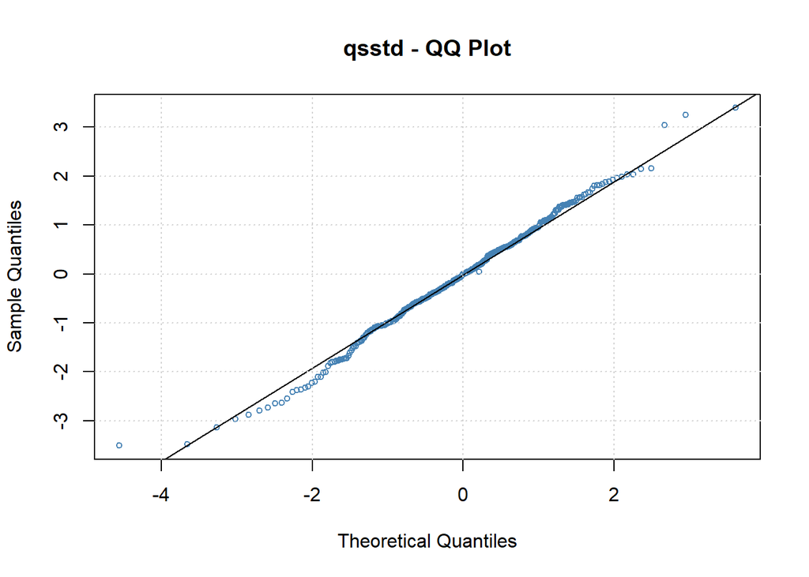

### Evaluate selected model

We first do a one-period-ahead forecast using the selected model, here we use rolling forecast method.

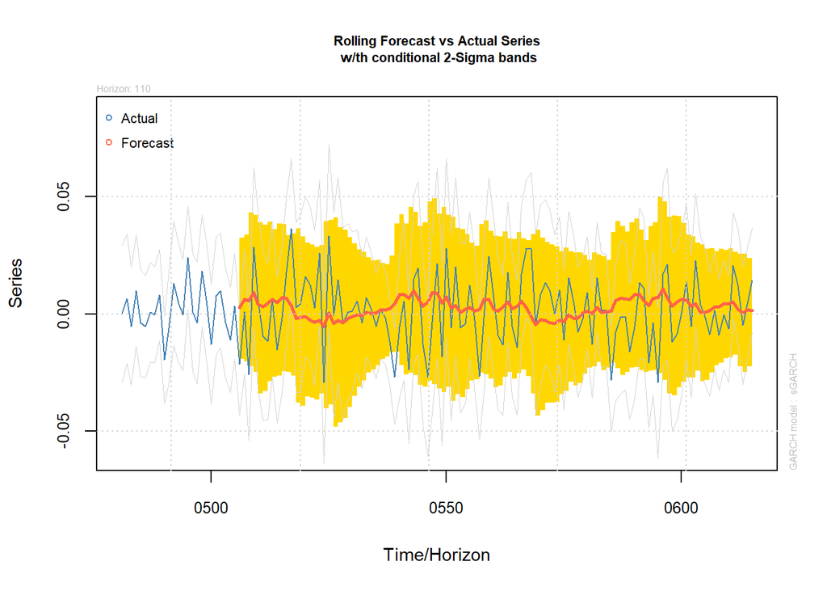

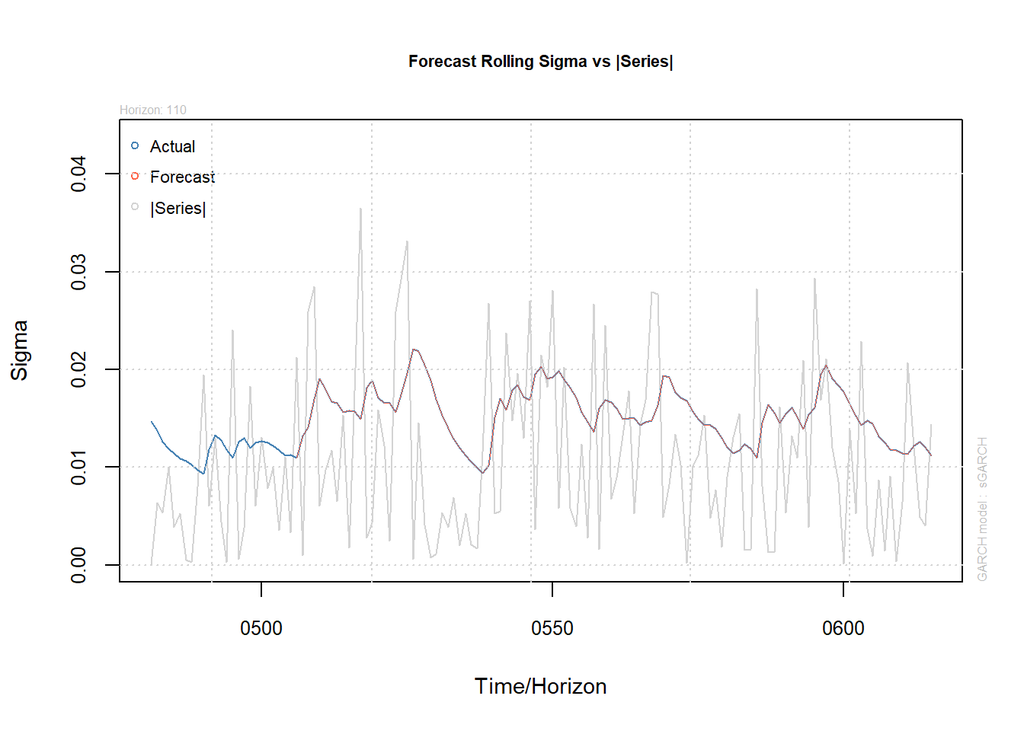

Now let’s take a look at the metrics of our model on out-of-sample data.

```
## [1] "RMSE of selected model: ARMA(1, 1)-GARCH(2, 1) with skew student distribution  0.013672"
```

Now let’s do a forecast with two aditional models, EGARCH and IGARCH and compare the results.

EGARCH:

```
## [1] "RMSE of EGARCH model 0.014105"
```

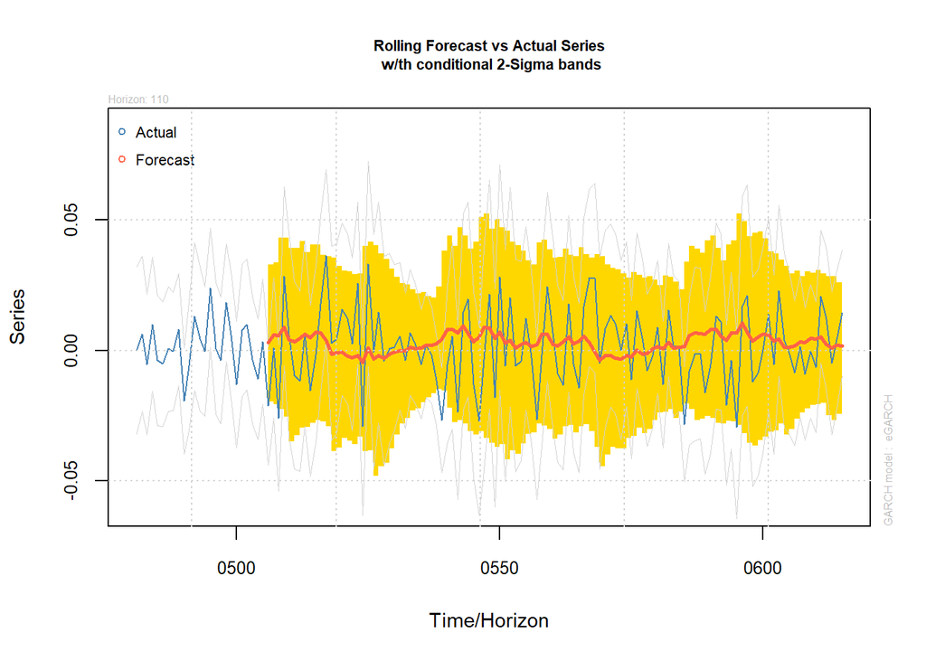

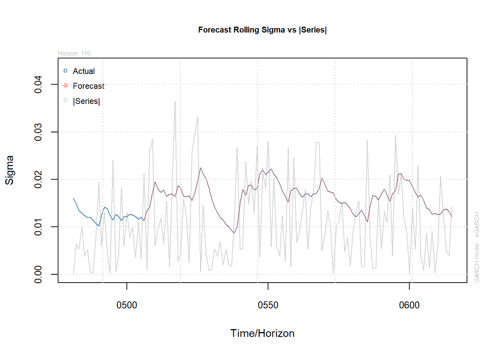

IGARCH:

```
## [1] "RMSE of IGARCH model 0.013615"
```

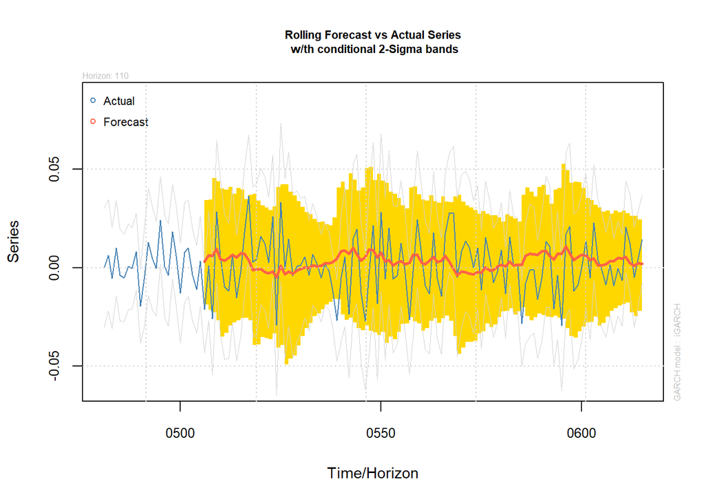

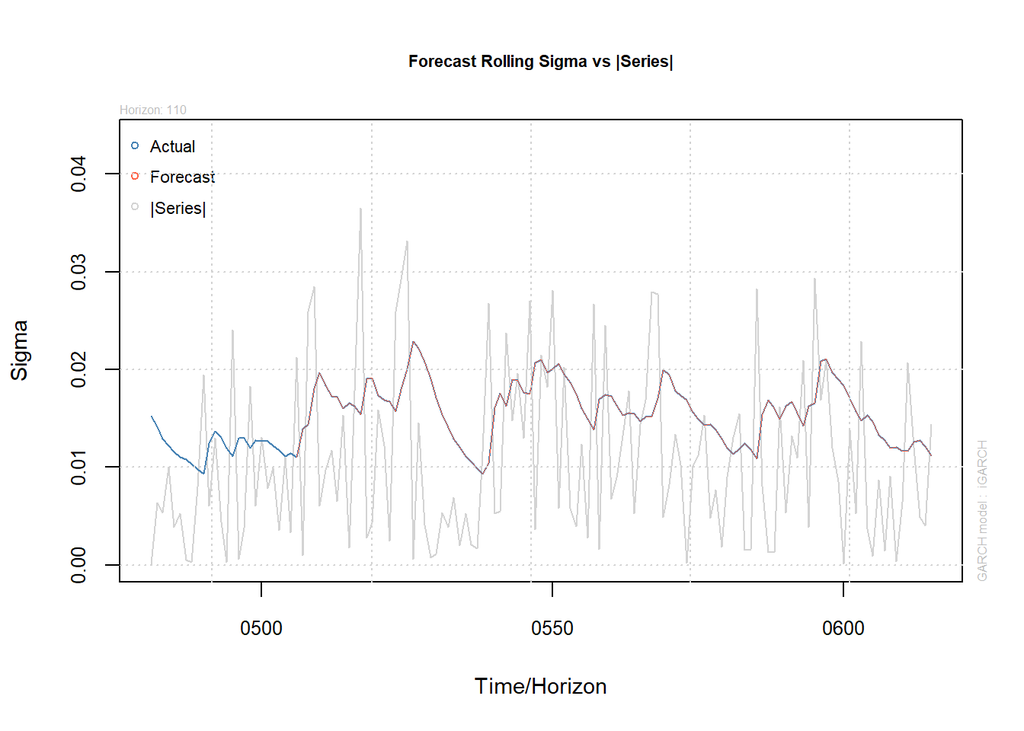

Root-mean-square error of all three models is pretty similar.

To further evaluate models, we use the Diebold-Mariano test to determine whether forecasts are significantly different.

Since p-value for both models comparison is zero (2.2e-16 and 1.55e-13) we reject the null hypothesis.

```
##
##  Diebold-Mariano Test
##
## data:  structure(abs(predictions_selected - target_values), class = "forecast")structure(abs(predictions_igarch - target_values), class = "forecast")
## DM = -12.492, Forecast horizon = 1, Loss function power = 2, p-value <
## 2.2e-16
## alternative hypothesis: two.sided
```

```
##
##  Diebold-Mariano Test
##
## data:  structure(abs(predictions_selected - target_values), class = "forecast")structure(abs(predictions_egarch - target_values), class = "forecast")
## DM = -8.4225, Forecast horizon = 1, Loss function power = 2, p-value =
## 1.55e-13
## alternative hypothesis: two.sided
```